# Appunti a margine di un esercizio modellistico: CALPUFF vs. AERMOD vs. LAPMOD

Il caso studio di una sorgente odorigena di tipo passivo

Massimo Bressan - ARPAV, DAPTV SMV

[last compiled on: 2020-11-25]

# 1 - Introduzione ed obiettivi

Considerate le sostanziali differenze tra sistemi modellistici basati su approcci di calcolo molto diversi si propone di seguito un confronto in termini operativi dei risultati di stima prodotti da:

- CALPUFF, ver. 5.8.5 (EPA approved), a puff, tridimensionale, non stazionario;
- AERMOD, ver. 19191 (EPA approved), gaussiano a pennacchio di tipo evoluto, stazionario;
- LAPMOD, ver. 20200629, lagrangiano a particelle, tridimensionale, non stazionario.

Dal punto di vista della pratica operativa (cioè di utilizzo e confronto di differenti output modellistici) l’obiettivo principale del presente documento è sinteticamente riassumibile in:

- una verifica del grado di convergenza delle stime prodotte da differenti modelli in relazione ai molteplici parametri di set-up dei runs di calcolo cioè, in altri termini, un’analisi di sensitività dei risultati rispetto all’utilizzo di differenti sistemi modellistici e relative parametrizzazioni di input;

E’ quindi del tutto evidente che non si tratta qui di un confronto modellistico dal punto di vista ‘teorico’ ma semplicemente di una **annotazione sistematica delle difficoltà, delle incertezze e dei trade-offs che operativamente si devono fronteggiare al fine di assicurare, per quanto possibile, sufficiente consistenza, precisione ed accuratezza dei risultati di stima.**

E’ d’altro canto evidente che tutti questi aspetti hanno una significativa rilevanza in termini di interpretazione dei risultati da parte degli operatori di settore, degli utenti finali e di tutti gli attori che sono a vario titolo coinvolti direttamente od indirettamente quali principali ‘destinatari’ delle stime modellistiche.

# 2 - La sorgente

L’insediamento industriale, ubicato nel Comune di Moriago della Battaglia (TV), svolge attività di macellazione di carni bovine con autorizzazione AIA.

La sorgente odorigena di tipo passivo è rappresentata dalle vasche e sezioni di depurazione e trattamento fanghi dell’impianto aziendale.

Le emissioni odorigene sono prodotte dalle sezioni impiantistiche di:

- ingresso con equalizzazione del refluo
- fanghi attivi con nitrificazione ed ossidazione
- ispessimento e disidratazione dei fanghi/digestato con stoccaggio in concimaia.

Nell’impianto industriale sono state individuate le seguenti tipologie di sorgenti odorigene:

- V1: vasca di equalizzazione
- V2A: vasca di ossidazione primaria
- V2B: vasca di ossidazione primaria
- V3A: vasca di ossidazione secondaria
- V3B: vasca di ossidazione secondaria
- V4: concimaia

che, in riferimento ai risultati di un’indagine olfattometrica, hanno registrato quanto segue:

| sorgente | area tot [m2] | SOER [ouE/(m2 s)] | OER [ouE/s] |
| --- | --- | --- | --- |
| V1 | 64 | 113 | 7232.0 |
| V2A | 216 | 5.3 | 1144.8 |
| V2B | 84 | 5.3 | 445.2 |
| V3A | 144 | 0.7 | 100.8 |
| V3B | 144 | 0.7 | 100.8 |
| V4 | 280 | 3.9 | 1092.0 |

I ratei di emissione specifici (SOER) per le sorgenti V2B e V3B sono stati aattributi (assegnazione esperta) in termini equivalenti rispetto a quelli misurati presso le sorgenti V2A e V3A.

Da rilevare che sorgenti emissive con portata di odore (OER) inferiori a 500 ouE/s sono tipicamente considerate poco significative e sono state incluse nella presente valutazione solo per completezza di informazione.

> Il presente esercizio modellistico è riferito ad un layout impiantistico ‘superato’ che non trova effettivo riscontro nella configurazione industriale in esercizio e, quindi, i risultati modellistici di seguito proposti non hanno alcun valore in termini di una valutazione dell’attuale impatto ambientale della sorgente emissiva considerata.

# 3 - CALPUFF

Iniziamo con la presentazione dei risultati di stima CALPUFF che rappresenta il riferimento ‘base’ in termini di input ‘micro-meteo’ da cui poi sono derivate tutte le altre stime modellistiche (AERMOD e LAPMOD).

## 3.1 - Configurazione di base

- intervallo temporale 1 anno (2019)
- COSMO-LAMI 7
  - velocità e direzione vento, temperatura, umidità relativa
  - griglia: 5 * 5 (5 km)
  - dominio: 25 km * 25 km
- CALMET (v. 5.8.5, EPA approved)
  - orografia e uso suolo: DTM 250 m
  - griglia: 51 * 51 (250 m)
  - dominio: 12.75 km * 12.75 km
- CALPUFF (v. 5.8.5, EPA approved)
  - sorgente areale
  - dominio: 5 km * 5 km (centrato su sorgente)
  - cella di campionamento: 50 m, nesting factor MESHDN = 5
  - coeff. disp. da variabili micro-meteo, MDISP = 2
  - no reazioni chimiche, no deposizione secca e umida
  - puffs ‘da seguire’ - to track -, NPFDEB = 10
  - min vv per ‘non calma’: 0.5 m/s

## 3.2 - Breve caratterizzazione ‘micro-meteo’

rosa dei venti: stratificazione per mese

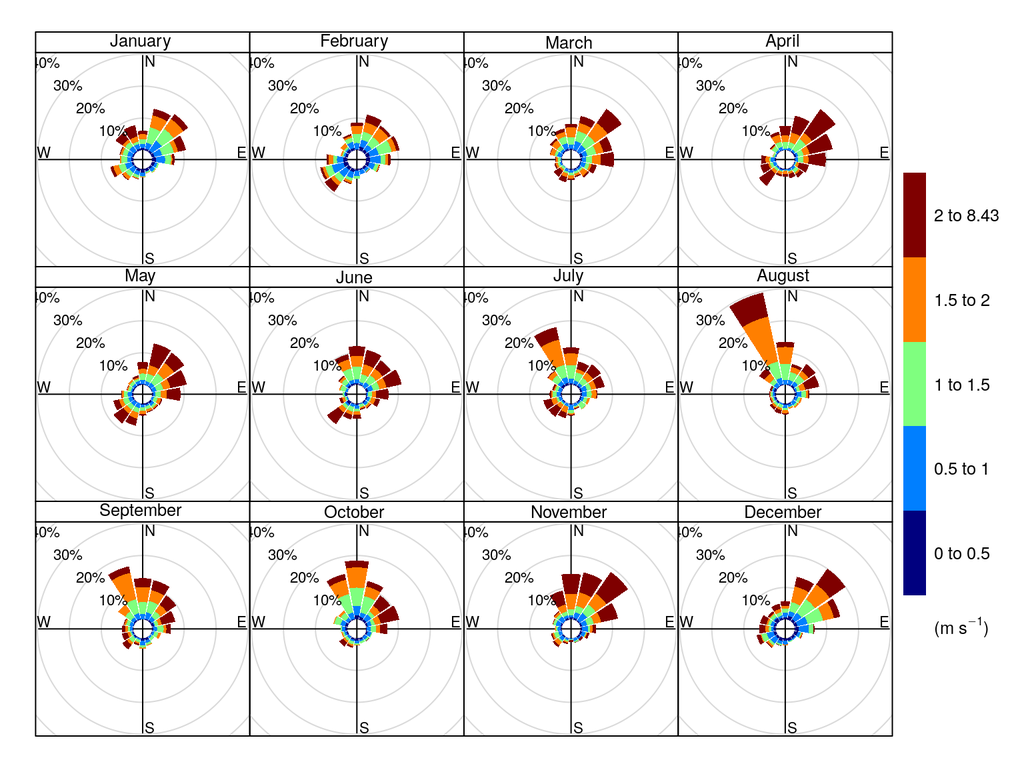

frequenza velocità vento: statistiche per mese e grafico distribuzione per classi discrete di intensità

| month | n | mean | sd | min | max | median |
| --- | --- | --- | --- | --- | --- | --- |
| 01 | 743 | 1.4 | 0.9 | 0.0 | 5.9 | 1.2 |
| 02 | 672 | 1.2 | 0.7 | 0.0 | 4.0 | 1.1 |
| 03 | 744 | 1.6 | 0.9 | 0.1 | 7.2 | 1.5 |
| 04 | 720 | 2.2 | 1.2 | 0.1 | 8.4 | 2.0 |
| 05 | 744 | 1.8 | 1.0 | 0.1 | 6.4 | 1.6 |
| 06 | 720 | 1.7 | 0.9 | 0.1 | 5.9 | 1.6 |
| 07 | 744 | 1.6 | 0.9 | 0.1 | 6.2 | 1.5 |
| 08 | 744 | 1.6 | 0.7 | 0.0 | 4.5 | 1.6 |
| 09 | 720 | 1.6 | 0.8 | 0.1 | 5.4 | 1.5 |
| 10 | 744 | 1.4 | 0.7 | 0.0 | 4.9 | 1.4 |
| 11 | 720 | 1.9 | 1.2 | 0.0 | 6.7 | 1.7 |
| 12 | 744 | 1.4 | 0.8 | 0.0 | 6.1 | 1.3 |

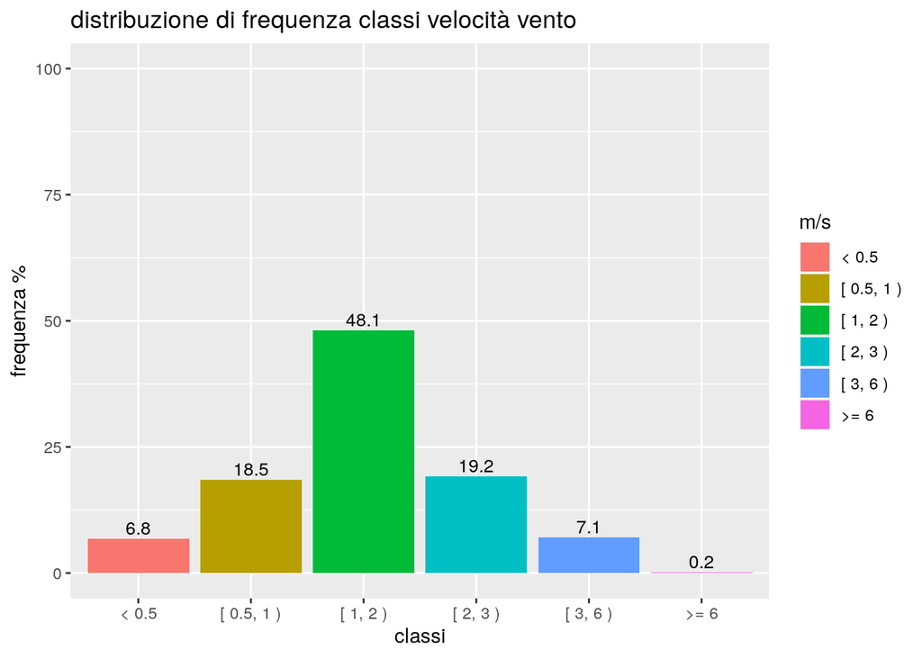

altezza di rimescolamento: stratificazione per mese

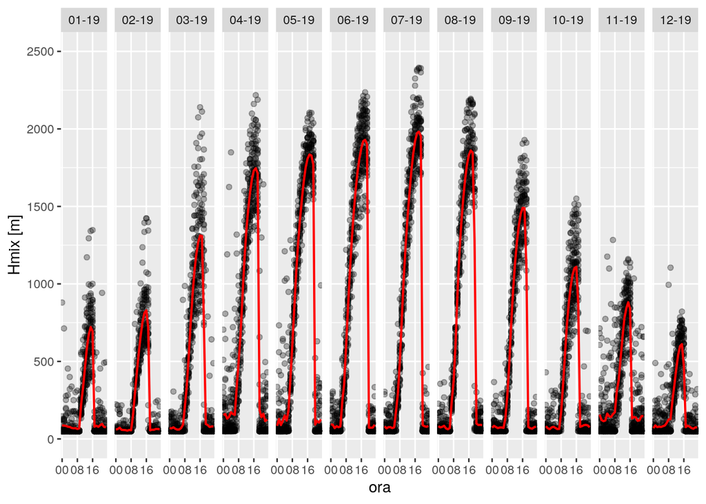

## 3.3 - Stima CALPUFF come sorgente ‘areale’

La sorgente di emissione è stata approssimata di tipo ‘areale’ con una dimensione verticale iniziale (sigma z) del plume posta pari a zero per garantire confrontabilità con quanto impostato nel run AERMOD (cfr. successive specifiche per quanto riguarda la carattterizzazione di sorgenti areali passive contenute nel manuale AERMOD).

E’ da considerare con attenzione che per le sorgenti areali CALPUFF utilizza un algoritmo di calcolo differente (virtual point) rispetto al corrispondente utilizzato da AERMOD (cfr. seguenti).

from: Calpuff User Guide (p 2-134)

> A specialized algorithm is used to simulate concentrations within and downwind of area sources. The original CALPUFF model approximated all area sources using the virtual point source method in which the overall size of the area source was represented by an initial sigma y. While such an approach is reasonable far from the area source, it becomes a poor approximation nearby, or for receptors embedded within, a large area source.

Di seguito sono presentate le statistiche e le relative mappe di concentrazione orarie relative alla media di periodo (annuale), al 98° ed al 99° percentile, ed infine al valore massimo di dominio spaziale.

| statistica | valore max dominio |
| --- | --- |
| AVG | 25 |
| P98 | 124 |
| P99 | 127 |
| MAX | 144 |

*Nota*: la valutazione delle concentrazione media annuale di odore non ha alcun senso dal punto di vista ambientale e del relativo impatto ma serve solo per una verifica del grado di convergenza delle stime prodotte dai differenti modelli a confronto sul ‘lungo periodo’; rispetto a questo specifico parametro di valutazione si astrae quindi dagli aspetti relativi alla valutazione di impatto odorigeno e si si rientra nella logica più ampia della valutazione media di periodo di un generico inquinante (trattato in forma di gas).

Nelle mappe che seguono (interattive e sincronizzate) sono riportate per ogni statistica (media periodo, P98, P99, max) il valore massimo di dominio ed il centroide del punto di emissione (inoltre, nel menu a sinista è possibile visualizzare un ‘controur plot’ delle relative concentrazioni ambientali stimate, cambiare il layer di visualizzazione di base e misurare la distanza tra punti nella mappa).

[interactive chart not shown]

### 3.3.1 - Sintesi per punti

- i massimi spaziali di dominio per le statistiche relative a media di periodo (AVG), 98° percentile (P98), 99° percentile (P99) e massimo orario (MAX) di concentrazione odorigena ricadono sempre nelle immediate vicinanze del punto di emissione (ubicato a circa 50 metri dal ‘centroide’ della sorgente);
- i massimi spaziali di dominio stimati per le statistiche relative a 98° percentile (P98), 99° percentile (P99) e massimo orario (MAX) di concentrazione odorigena sono molto simili in termini assoluti (cfr. tabella precedente);
- l’impatto rende conto di valori di concentrazione odorigena molto significativi (>10 uoE/m3) entro 200-250 m circa dal punto di emissione (‘centroide’ della sorgente);
- oltre i 250 m di distanza dal punto di emissione (‘centroide’ della sorgente) i valori di concentrazione stimati dal modello diminuiscono molto rapidamente, da circa 5-10 uoE/m3 fino a raggiungere valori poco significativi o del tutto trascurabili (<< 1 uo/m3);

# 4 - AERMOD

Presentazione dei risultati di stima nell’approssimazine della sorgente di emissione rispettivamente modellizzata come *areale* e *volumetrica*.

Significative differenze sono state riscontrate nei valori stimati in funzione del tipo di sorgente considerata (areale vs. volumetrica) e quindi alle assunzioni di calcolo e degli algoritmi specifici utilizzati dal modello.

## 4.1 - Configurazione di base

- estrazione CALMET su punto sorgente
- CALMET interpolazione e ‘correzione’ per uso del suolo ed orografia delle variabili meteo (temp, ws, wd, prec, srad, rhu, tcc, press) da ‘punti LAMI’
- dominio: 5 km * 5 km (centrato sul punto sorgente)
- parametri superficiali (landuse 1 km):
  - albedo = 0.16
  - bowen ratio = 0.84
  - roughness length = 1.00

## 4.2 - Stima AERMOD come sorgente ‘areale’

La sorgente di emissione è stata approssimata come ‘areale’ caratterizzata da una dimensione verticale iniziale (sigma) del plume posta pari a zero (Szinit = 0), al fine di garantire, per quanto è possibile, un sufficiente grado di confrontabilità con le impostazioni degli altri runs modellistici.

from AERMOD User Guide (p. 3-89)

> The optional Szinit parameter may be used to specify an initial vertical dimension to the area source plume, similar to the use of the Szinit parameter for volume sources. This parameter may be important when the area source algorithm is used to model mechanically generated emission sources, such as mobile sources. In these cases, the emissions may be turbulently mixed near the source by the process that is generating the emissions, and therefore occupy some initial depth. For more passive area source emissions, such as evaporation or wind erosion, the Szinit parameter may be omitted, which is equivalent to using an initial sigma-z of zero.

Di seguito sono presentate le statistiche e le relative mappe di concentrazione orarie relative alla media di periodo (annuale), al 98° ed al 99° percentile, ed infine al valore massimo di dominio.

| statistica | valore max dominio |
| --- | --- |
| AVG | 57 |
| P98 | 385 |
| P99 | 480 |
| MAX | 751 |

*Nota*: vale quanto già detto in precedenza per il (non) significato ambientale del valore medio annuale delle concentrazioni di odore.

Da considerare con attenzione che la modellizzazione in AERMOD come sorgente areale comporta possibili conseguenze significative nei valori di stima (come riportato nel manuale - cfr. nota segeunte)

from: AERMOD Implementation Guide (p. 25)

> Because of issues related to excessive run times and technical issues with model formulation, the approach that AERMOD uses to address plume meander has not been implemented for area sources. As a result, concentration predictions for area sources may be overestimated under very light wind conditions (i.e., u << 1.0 m/s).  
> [ … ] During such conditions time-averaged plumes tend to spread primarily as a result of low frequency eddy translation rather than eddy diffusion.

e ancora riguardo alla possibile strategia per la risoluzione dei problemi di sovrastima:

> In order to avoid overestimates for area sources during light wind conditions, it is recommended that, where possible, a volume source approximation be used to model area sources. This approach can be applied with confidence for situations in which the receptors are displaced from the source. However, for applications where receptors are located either directly adjacent to, or inside the area source, AERMOD’s area source algorithm will need to be used. For these circumstances, caution should be exercised if excessive concentrations are predicted during extremely light wind conditions. On a case-by-case basis, the reviewing authority should decide whether such predictions are unrealistic. One possible remedy would be to treat such hourly predictions as missing data.

Rispetto alla stima prodotta con l’approssimazione di sorgente ‘areale’ è stato effettivamente verificato che i 50 valori di più alti delle medie orarie sono sempre riferiti a condizioni particolari con regime di vento molto debole (< 0.4 m/s) o quasi nullo, e quindi in buon accordo con quanto riportato nelle specifiche del manuale AERMOD.

Segue presentazione delle mappe interattive per la stima AERMOD come sorgente ‘areale’.

[interactive chart not shown]

### 4.2.1 - Sintesi per punti

- valgono le considerazioni già viste in precedenza sull’ubicazione dei massimi spaziali di dominio per le statistiche relative a media di periodo (AVG), 98° percentile (P98), 99° percentile (P99) e massimo orario (MAX) di concentrazione odorigena (ricadenti sempre a circa 50 metri dal ‘centroide’ della sorgente);
- i massimi spaziali di dominio stimati per le statistiche relative a 98° percentile (P98), 99° percentile (P99) e massimo orario (MAX) di concentrazione odorigena evidenziano valori molto elevati la cui spiegazione trova un significativo accordo con quanto indicato sulle specifiche tecniche dell’algoritmo di calcolo AERMOD per le sorgenti areali (cfr. tabella e nota precedente); i 50 valori più elevati di stima delle medie orarie (P98, P99, MAX) si verificano sempre in corrispondenza di condizioni di vento molto debole (< 0.4 m/s);
- i valori stimati da AERMOD nella configurazione ‘sorgente areale’ risultano significativamente più elevati dei corrispondenti valori stimati da CALPUFF (per le motivazioni sopra ricordate).

## 4.3 - Stima AERMOD come sorgente ‘volumetrica’

In questa sezione sono presentati i risultati di stima nell’approssimazione della sorgente emissiva di tipo volumetrico (da confrontare con i corrispondenti risultati per sorgente di tipo areale) in cui i parametri iniziali di sorgente sono stati posti pari a zero (Syinit e Szinit = 0) al fine di garantire, per quanto è possibile, un sufficiente grado di confrontabilità con le impostazioni degli altri runs modellistici.

Di seguito sono presentate le mappe e le relative statistiche di concentrazione oraria relative a media di periodo (annuale), al 98° ed al 99° percentile, ed infine al valore massimo di dominio.

| statistica | valore max dominio |
| --- | --- |
| AVG | 44 |
| P98 | 160 |
| P99 | 175 |
| MAX | 208 |

*Nota*: vale quanto già detto in precedenza per il (non) significato ambientale del valore medio annuale delle concentrazioni di odore.

Segue presentazione delle mappe interattive di stima AERMOD come sorgente ‘volumetrica’.

[interactive chart not shown]

### 4.3.1 - Sintesi per punti

- valgono le considerazioni già viste in precedenza sull’ubicazione dei massimi spaziali di dominio per le statistiche relative a media di periodo (AVG), 98° percentile (P98), 99° percentile (P99) e massimo orario (MAX) di concentrazione odorigena (ricadenti sempre a circa 50 metri dal ‘centroide’ della sorgente);
- i valori stimati da AERMOD nella configurazione ‘sorgente volumetrica’ risultano sostanzialmente congruenti con i valori stimati da CALPUFF (che utilizza un algoritmo di calcolo - virtual point - con un approccio paragonabile a quello utilizzato da AERMOD in configurazione sorgente ‘volumetrica’);
- nella configurazione come sorgente ‘volumetrica’ non si vcerificano gli elevati picchi di concentrazione delle medie orarie caratteristici invece della configurazione ‘areale’: il differente algoritmo di calcolo sembra quindi essere il fattore determinante nella sensitività dei valori di stima.

# 5 - LAPMOD

Presentazione dei risultati di stima LAPMOD nell’approssimazione di sorgente ‘areale’.

## 5.1 - Configurazione di base

- input meteo CALMET
- dominio. 5 km * 5 km (centrato su sorgente)
- cella di campionamento: 50 m
- CCA (Concentration Calculation Algorithm): classical LAPMOD method (gaussian kernel)
- number of particles emitted each 60 seconds = 60
- peak to mean modeling LPEAK = F, rateo costante = 2.3
- sigma z iniziale = 0 (per analogia a quanto impostato negli altri run modellistici)

## 5.2 - Stima LAPMOD come sorgente ‘areale’

Sono riportati i risultati di stima nell’approssimazione di sorgente areale (da confrontare con i precendenti risultati per sorgente areale e volumetrica) in cui i parametri iniziali di sorgente sono stati posti pari a zero (Syinit e Szinit = 0), al fine di garantire, per quanto è possibile, un sufficiente grado di confrontabilità con le impostazioni degli altri runs modellistici.

Seguono le statistiche e le relative mappe di concentrazione orarie relative alla media di periodo (annuale), al 98° ed al 99° percentile, ed infine al valore massimo di dominio.

| statistica | valore max dominio |
| --- | --- |
| AVG | 15 |
| P98 | 160 |
| P99 | 269 |
| MAX | 634 |

**NOTA**: vale quanto già detto in precedenza per il (non) significato ambientale del valore medio annuale delle concentrazioni di odore.

Segue presentazione delle mappe interattive per la stima LAPMOD (‘sorgente ’areale’).

[interactive chart not shown]

### 5.2.1 - Sintesi per punti

Considerati i differenti approcci modellistici, focalizzando l’attenzione essenzialmente sul risultato numerico di stima, si rileva che:

- valgono le considerazioni già viste in precedenza sull’ubicazione dei massimi spaziali di dominio per le statistiche relative a media di periodo (AVG), 98° percentile (P98), 99° percentile (P99) e massimo orario (MAX) di concentrazione odorigena (ricadenti sempre a circa 50 metri dal ‘centroide’ della sorgente);
- i valori stimati da LAPMOD (nella configurazione sorgente areale) per le statistiche relative a P98, P99 appaiono sostanzialmente confrontabili con i valori di stima per CALPUFF 8sorgente areale) e AERMOD (sorgente volumetrica); i valori di stima realtivi al valore massimo assoluto (MAX) risultano invece sensibilmente più alti e paragonabili a quelli di AERMOD nella configurazione sorgente areale.

# 6 - Valutazione comparata dei risultati

Nella tabella successiva viene riproposto il confronto dei valori massimi spaziali di domino delle statistiche relative alle concentrazioni medie orarie espresse in unità odorigene (uo/m3) per:

- media di periodo (AVG);
- 98° percentile (P98);
- 99° percentile (P99);
- valore massimo (MAX);

| statistica | CALPUFF (areale) | AERMOD (areale) | AERMOD (volumetrica) | LAPMOD (areale) |
| --- | --- | --- | --- | --- |
| AVG | 25 | 57 | 44 | 15 |
| P98 | 124 | 385 | 160 | 160 |
| P99 | 127 | 480 | 175 | 269 |
| MAX | 144 | 751 | 208 | 634 |

Nel grafico successivo viene rappresentato un confronto delle concentrazioni stimate presso alcuni recettori discreti posizionati a distanze crescenti dal centroide del punto di emissione (50 m, 100 m, 300 m, 500 m) lungo le direzioni corrispondenti ai punti cardinali N, S, E, W.

Il confronto dei valori stimati lungo i 4 ‘transetti’ individuati lungo gli assi cardinali (N, S, E, W) è riferito alle principali statistiche (avg, p98, p99, max) prodotte dai differenti approcci modellistici nelle varie configurazioni utilizzate nel presente caso studio (CALPUFF area vs AERMOD area vs. AERMOD volume vs. LAPMOD area).

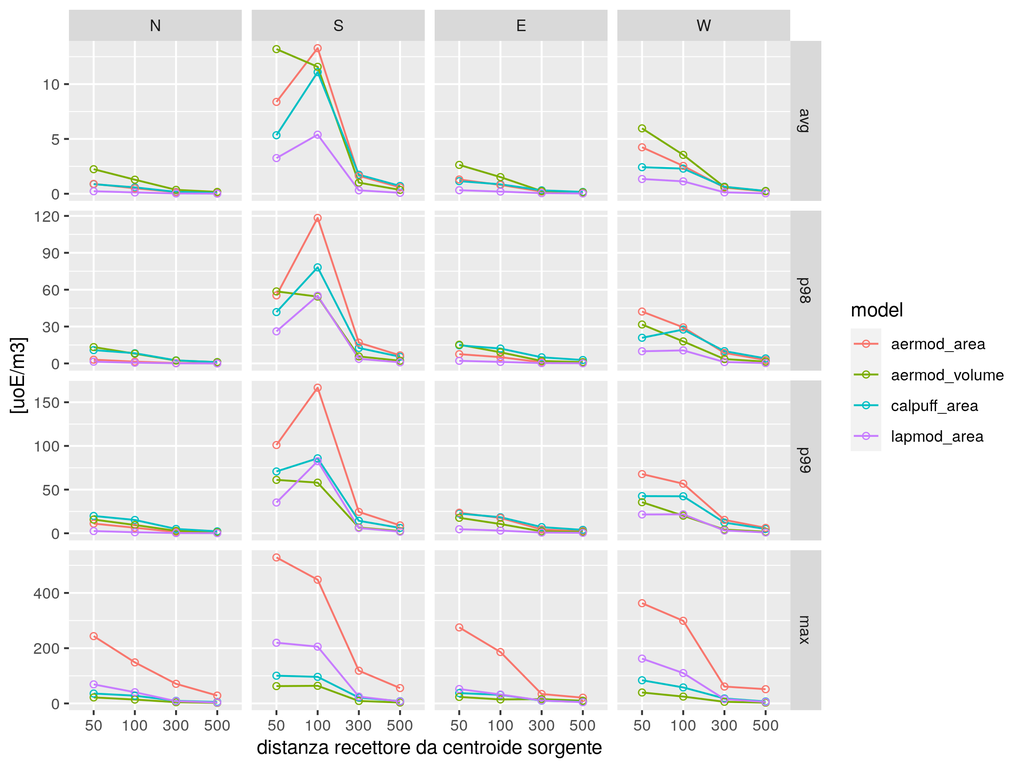

## 6.1 - Distanza di separazione

Con l’obiettivo di confrontare tramite una ‘metrica comune’ i risultati di run modellistici che spesso risultano difficilmente comparabili, sia nel tempo che nello spazio, viene di seguito proposto il calcolo della ‘distanza di separazione’, cioè la misura della distanza fisica che individua i punti delle isoplete di concentrazione ambientale fissate ad un predeterminato livello soglia per una specifica probabilità (98° percentile delle concentrazioni ambientali pari ai livelli di 1, 3, 5 uoE/m3).

Il grafico rappresenta per ciascuna configurazione modellistica la distanza misurata tra il punto di sorgente (centroide) e i punti lungo le isoplete che individuano le concentrazioni di 1, 3, 5 uoE/m3 relative al 98° percentile orario, calcolata ad una prefissata coordinata orizzontale angolare (azimut) rispetto al Nord (bearing angle) con un passo di 5 gradi di ampiezza (da 0 a 360).

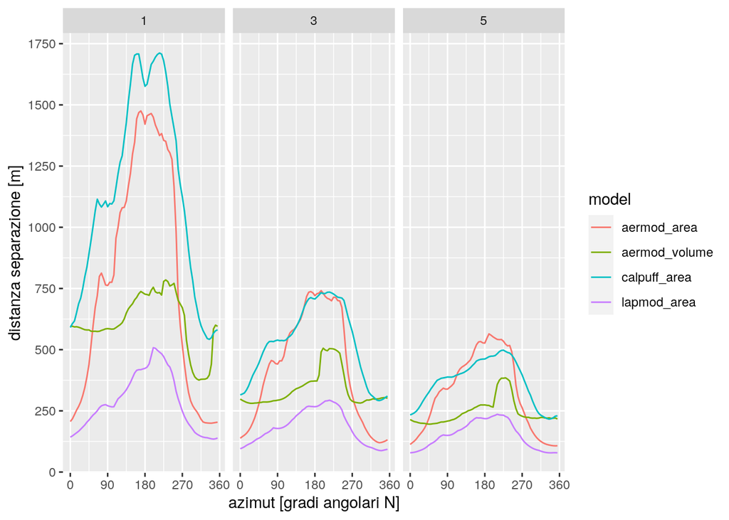

Sembra quindi emergere, in termini più generali, la spiccata attitudine di CALPUFF quale modello a ‘mesoscala’, la significativa differenza nei risultati di AERMOD in funzione dell’algoritmo utilizzato per la caratterizzazione della sorgente (area vs. volume) e, per finire, la caratteristica tendenza di LAPMOD a ‘lavorare su distanze più brevi’, con una maggiore propensione per la valutazione nel ‘campo vicino’.

E’ comunque evidente che la ‘forma’ delle isoplete risulta significativamente condizionata dalla direzione e velocità del vento che viene rappresentata come rosa del vento realtiva al punto corrispondente al centro del dominio di calcolo.

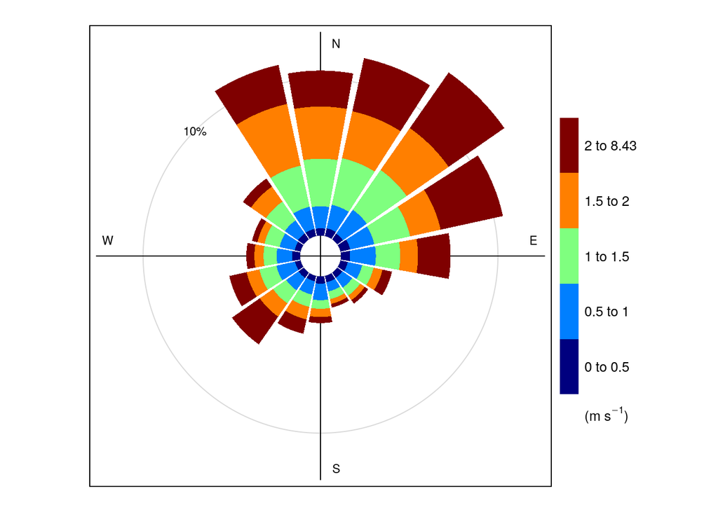

Il senso autentico di tali considerazioni emerge molto più chiaramente dalla valutazione comparata delle mappe interattive di seguito riportate.

[interactive chart not shown]

Le mappe sincronizzate riportano per ciascun run modellistico (CALPUFF area vs AERMOD area vs. AERMOD volume vs. LAPMOD area) le isoplete (isolinee) corrispondenti ai valori di 1, 3, 5 uoE/m3 relativamente al 98° percentile delle medie orarie (su base annuale).

Considerata una specifica mappa e fissato un punto preciso lungo una isopleta che individua una specifica concentrazione relativa ad una predeterminata configurazione modellistica, si evidenzia il corripondente valore di distanza (e di concentrazione) stimato nello stesso punto delle altre mappe, cioè il corripondente valore stimato dalle altre configurazioni modellistiche.

# 7 - Alcune conclusioni operative

Concludendo, sinteticamente per punti:

- i massimi spaziali di dominio per le statistiche relative a media di periodo (AVG), 98° percentile (P98), 99° percentile (P99) e massimo orario (MAX) di concentrazione odorigena ricadono sempre nelle immediate vicinanze del punto di emissione (ubicato a circa 50-100 metri dal ‘centroide’ della sorgente);
- oltre i 300 m di distanza dal punto di emissione (‘centroide’ della sorgente) i valori di concentrazione stimati dal modello diminuiscono molto rapidamente fino a raggiungere valori poco significativi o del tutto trascurabili (i valori decrescono molto rapidamente entro un raggio di poche centinaia di metri);
- è da valutare con attenzione la significatività delle stime dei valori massimi registrati nel ‘campo vicino’, cioè a breve distanza dalla sorgente (tipcamente entro 50-100 m) in funzione del tipo di modello utilizzato e dell’approssimazione di sorgente adottata (areale vs. volumetrica);
- i risultati di stima ottenuti con i differenti modelli a confronto sembrano sostanzialmente coerenti fatta la rilevante eccezione di alcune configurazioni che utilizzano algortimi di stima che hanno l’effetto di produrre risultati molto differenti (i più alti in valore assoluto nel caso di AERMOD con caratterizzazione di sorgente areale);
- la valutazione della distanza di separazione permette di comparare in modo efficace i risultati prodotti da differenti configurazioni modellistiche individuando in modo preciso l’estensione areeale del dominio di calcolo soggetto al maggiore impatto.
- la configurazione adottata per AERMOD al fine di caratterizzare il tipo di sorgente (areale vs. volumetrica) sembra essere un fattore deteriminante (critico) nella sensitività dei risultati ottenuti;

> Dal punto di vista metodologico c’è da considerare che per le sorgenti volumetriche si introduce il concetto di “exclusion zone” che corrisponde ad un’area di raggio pari a metri 2.15*[SigmaY+1] e che rappresenta il dominio di calcolo all’interno della quale tutte le concentrazioni sono forzate a zero dal modello. Nelle simulazioni qui presentate è stato imposto SigmaY=0 e conseguentemente la “exclusion zone” è risultata di raggio pari ad 1, e quindi senza alcun significativo effetto sui risultati di stima. Tipicamente SigmaY viene stimata come [ampiezza sorgente]/4.3, e SigmaZ come [altezza sorgente]/4.3; in altri casi, quando la sorgente è posizionata al suolo, al denominatore si utilizza il valore 2.15. E’ quindi importante verificare che la “exclusion zone” non alteri in modo significativo i risultati di stima escludendo aree del dominio di calcolo che sono immediatamente a ridosso del perimetro dell’impianto in cui è inserita la sorgente da modellizzare (cfr. [report EPA 2012](https://www3.epa.gov/scram001/reports/Haul_Road_Workgroup-Final_Report_Package-20120302.pdf)).

# 8 - Ulteriori valutazioni

Traccia di un possibile piano di lavoro futuro:

- utilizzo del modello LAPMOD *specificamente* finalizzato allo studio di dispersione degli inquinanti odorigeni in relazione a:
  - possibilità di applicare un valore ‘Peak to Mean Ratio’ (PMR) variabile cioè non costante nello spazio (con funzione di attenuazione esponenziale); la ‘tipica’ ed ormai consolidata applicazione di PMR costante prevede un fattore moltiplicativo pari a 2.3 (che è un approccio concettualmente sbagliato perchè introduce delle approssimazioni ed assunzioni di carattere teorico difficilmente verificabili);
  - utilizzo del postprocessore LAPOST per il calcolo dei parametri FIDOL (Frequency, Intensity, Duration, Offensivenes, Location) relativi alla caratterizzazione dell’impatto odorigeno (ad esclusione del parametro Offensiveness che dipende da caratteristiche strettamente soggettive e dal tipo di ‘miscela odorigena’ considerata);
- verifica degli eventuali effetti sulle stime LAPMOD ed analisi di sensitività dei risultati in funzione dell’utilizzo di differenti parametrizzazioni per:
  - algoritmo di calcolo delle concentrazioni (CCA - Concentration Calculation Algorithm): gasussian kernel vs. uniform kernel vs. parabolic kernel vs. kernel smoother;
  - postprocessore LAPCON che effettua il calcolo delle concentrazioni tramite il metodo del conteggio delle particellein funzione del numero di particelle emesse nell’unità di tempo (NPART);
  - numero di campionamenti delle concentrazioni tra due output temporali consecutivi (NSAM) e tipo di campionamento (SAMTYPE - valore medio vs. massimo);
  - caratterizzazione ‘micro-meteo’ alternativa tramite il preprocessore LAMPET che utilizza ‘input files AERMET’ (‘SFC’ surface + ‘PFL’ profile);
- runs LAPMOD e CALPUFF in configurazione sorgente ‘volumetrica’ e relativa analisi di sensitività dei risultati (è da valutare l’effettiva significatività ed utilità pratica di queste due ulteriori stime modellistiche per il caso studio in esame).